# Gun-violence-Rapport

Felin Rémi, Vighi Alexis, Mosbah Yasmin

05/01/2020

# Sujet : Gun Violence Data

## Énoncé :

Il s’agira de mener une série de statistiques sur l’archive du même intitulé. Cet archive (au format CSV) contient des entrée relative aux faits divers causés par des armes à feu qui ont eu lieu aux Etats Unis entre le 1er janvier 2013 et le 31 mars 2018. Il s’agira de montrer l’évolution d’un certain nombre de variables pendant la période concernée, d’en calculer la moyenne et l’écart type (quand cela est possible). L’ensemble des variables qui nous intéressent contient : — nombre de blessés ; — nombre de morts ; — nombre de malfaiteurs ; — age des malfaiteurs ; — état dans lequel le fait divers a eu lieu.

## Analyse du sujet :

Le sujet nous demande ici d’étudier une base de donnée regroupant diverses informations sur des faits causés par les armes aux Etats Unis entre le 1er Janvier 2013 et le 31 Mars 2018. Le but de cet étude est d’observer l’évolution de certaines variables au fur et a mesure du temps. C’est variables concerne le nombre de blessés, le nombre de morts, le nombre de malfaiteurs, leur age et l’état dans lequel le fait divers a eu lieu.

### Description des données utilisées :

Les données de cette étude ont été récoltés par une société à but non lucratif crée en 2013 pour fournir un accès au public des informations précises sur la violence liée aux armes à feu aux États-Unis. Cette société a collecté et vérifié l’exactitude des informations. La base de donnée comporte pas moins de 260 000 incidents de violence armée survenue entre entre le 1er Janvier 2013 et le 31 Mars 2018 aux Etats Unis. Les données sont triées par date (ordre croissant). Chaque donnée comporte une variété d’informations, dont un id, une date, l’état ou s’est déroulé le crime, la ville, l’adresse, le nombre de morts, le nombre de blessés, le type d’arme utilisé, le nombre d’armes a feu et même l’age et le genre des participants.

### Librairie utilisée :

```r
library(knitr)
library(dplyr)
library(readr)
library(ggplot2)
library(tibble)
library(stringr)
library(gridExtra)
library(scales)
library(lubridate)
library(ggrepel)
library(leaflet)
library(rgdal)
library(tibble)
library(purrr)
library(splitstackshape)
library(PerformanceAnalytics)
library(tidyr)
library(corrplot)

library(lubridate)
```

### Optimisation de la base de données pour facilité son utilisation :

On commence par créer une dataframe (df) en indiquant que tout les NA et les espaces sont des NA :

```r
df = read.csv('C:/Users/Yasmin/Documents/M1MIAGE/Data BASE/soutenance/Projet-R-Gun-violence-data/data/gun-violence-data.csv', header=TRUE,stringsAsFactors = FALSE, na.strings=c("NA", ""))
```

Nous supprimons les colonnes inutiles dans une nouvelle dataframe (df1):

```r
df1 <- subset(df, select = -c(incident_url_fields_missing,location_description,notes,incident_url,incident_characteristics,longitude,latitude,sources, source_url))

#Valeurs manquantes
apply(df1, 2, function(col)sum(is.na(col))/length(col))
```

```
##              incident_id                     date                    state
##               0.00000000               0.00000000               0.00000000
##           city_or_county                  address                 n_killed
##               0.00000000               0.06883013               0.00000000
##                n_injured   congressional_district               gun_stolen
##               0.00000000               0.04983373               0.41513370
##                 gun_type          n_guns_involved          participant_age
##               0.41493760               0.41493760               0.38509327
##    participant_age_group       participant_gender         participant_name
##               0.17573234               0.15171251               0.51007397
## participant_relationship       participant_status         participant_type
##               0.93418643               0.11526346               0.10373544
##     state_house_district    state_senate_district
##               0.16176771               0.13491073
```

Nous récoltons une base de données ne comportant que les variables qui nous intéressent. Cette base de donnée contient beaucoup de valeurs manquantes. Alors nous mesurons en pourcentage la qualité des données de chaque colonnes pour ensuite supprimer celles qui ont plus de 40% de valeurs manquantes :

```r
#We'll delete all the columns with more than 40% of missing values
df1 <- subset(df1, select = -c(gun_stolen,gun_type,n_guns_involved,participant_name,participant_relationship))
apply(df1, 2, function(col)sum(is.na(col))/length(col))
```

```
##            incident_id                   date                  state
##             0.00000000             0.00000000             0.00000000
##         city_or_county                address               n_killed
##             0.00000000             0.06883013             0.00000000
##              n_injured congressional_district        participant_age
##             0.00000000             0.04983373             0.38509327
##  participant_age_group     participant_gender     participant_status
##             0.17573234             0.15171251             0.11526346
##       participant_type   state_house_district  state_senate_district
##             0.10373544             0.16176771             0.13491073
```

Fondamentalement, nous devrions supprimer participant_age, car cette colonne contient 38,5 % de données manquantes, Mais nous devons le garder pour l’étude.

Nous effaçons toutes les valeurs manquantes, nous pourrions les remplacer par la méthode Miss FAMD, mais comme nous ne faisons pas de machine learning ce n’est pas nécessaire.

```r
df1=na.omit(df1)
```

Nous formatons certaines données (celles comportant des : ||) afin d’avoir des valeurs numériques et une meilleure lisibilité:

```r
#We'll change some data for the readibility of them
age=cSplit(df1,c("participant_age"),sep="||",direction="wide",drop=FALSE)
age$age=gsub(".*::","",age$participant_age)
age$age=as.numeric(age$age)

df1$participant_age=age$age

type=cSplit(df1,"participant_status",sep="||" ,direction="wide",drop=FALSE)
type$participant_status=gsub(".*::","",type$participant_status)

df1$participant_status=type$participant_status

type=cSplit(df1,"participant_age_group",sep="||",direction="wide",drop=FALSE)
type$participant_age_group=gsub(".*::","",type$participant_age_group)

df1$participant_age_group=type$participant_age_group

type=cSplit(df1,c("participant_gender"),sep="||",direction="wide",drop=FALSE)
type$participant_gender=gsub(".*::","",type$participant_gender)
df1$participant_gender=type$participant_gender

type=cSplit(df1,c("participant_type"),sep="||",direction="wide",drop=FALSE)
type$participant_type=gsub(".*::","",type$participant_type)

df1$participant_type=type$participant_type
```

Nous créons une nouvelle dataframe(df2) à partir des colonnes de la précédentes dataframes(df1) en gardant seulement les colonnes désiré pour l’étude :

```r
#Now, after some preprocessing and the reorganization of the columns, we will kept only the
#columns needed.
#State, n_killed, n_injured, participant_ages
df2 <- subset(df1, select = c(n_killed, n_injured, state, participant_age))
head(df2)
```

```
##   n_killed n_injured          state participant_age
## 2        1         3     California              20
## 3        1         3           Ohio              33
## 4        4         0       Colorado              33
## 5        2         2 North Carolina              47
## 6        4         0       Oklahoma              55
## 7        5         0     New Mexico              15
```

Nous supprimons les NA qui restent et les valeurs peu probables :

```r
#We delete the last NA
df2=na.omit(df2)
summary(df2$participant_age)
```

```
##    Min. 1st Qu.  Median    Mean 3rd Qu.    Max.
##    0.00   21.00   26.00   29.67   35.00  209.00
```

```r
#We can see a crazy value, we will delete it
df2 <- df2[-which(df2$participant_age==209),]
dfnum <- subset(df2, select = c(n_killed, n_injured, participant_age))
```

### Première question :

#### Est-ce qu’il y a des corrélations (linéaires) entre les variables de V ?

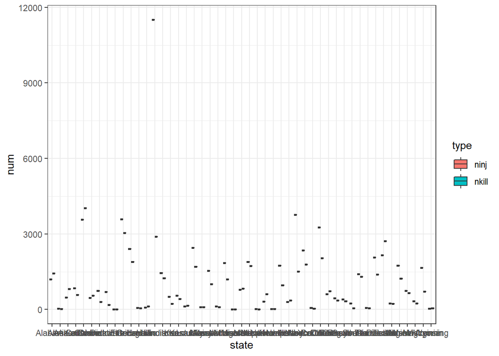

```r
bystate <- df2 %>% group_by(state) %>% summarize(n = n(), nkill = sum(n_killed), ninj = sum(n_injured)) %>% tidyr::gather(key = "type", value = "num", nkill, ninj)
ggplot(bystate, aes(x = state, y = num, fill = type)) + geom_boxplot() + theme_bw()
```

```r
summary(df2$participant_age)
```

```
##    Min. 1st Qu.  Median    Mean 3rd Qu.    Max.
##    0.00   21.00   26.00   29.67   35.00  101.00
```

```r
cor(dfnum, method = c("pearson", "kendall", "spearman"))
```

```
##                   n_killed  n_injured participant_age
## n_killed         1.0000000 -0.1601249       0.1224553
## n_injured       -0.1601249  1.0000000      -0.1073301
## participant_age  0.1224553 -0.1073301       1.0000000
```

```r
mcor <- cor(dfnum)
mcor
```

```
##                   n_killed  n_injured participant_age
## n_killed         1.0000000 -0.1601249       0.1224553
## n_injured       -0.1601249  1.0000000      -0.1073301
## participant_age  0.1224553 -0.1073301       1.0000000
```

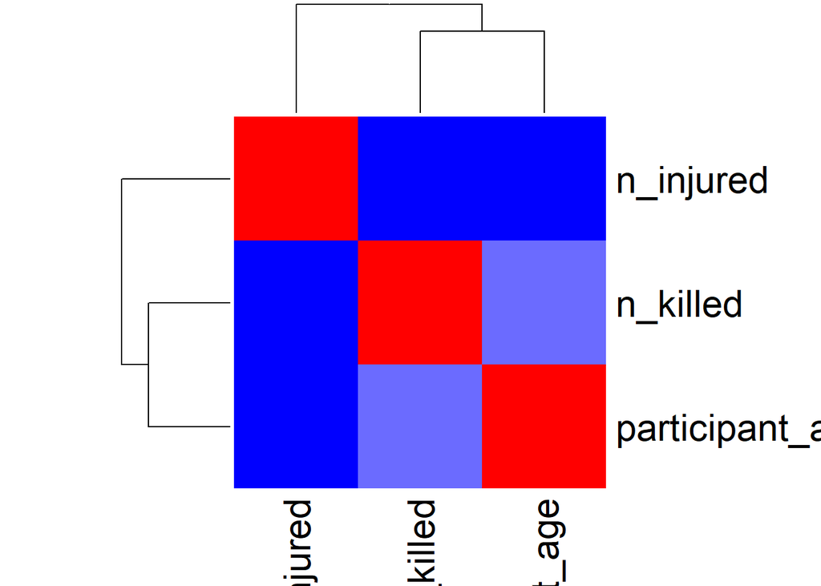

```r
col<- colorRampPalette(c("blue", "white", "red"))(20)
heatmap(x = mcor, col = col, symm = TRUE)
```

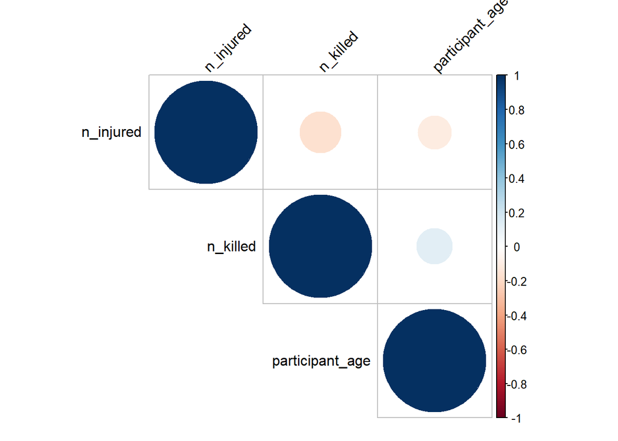

```r
corrplot(mcor, type="upper", order="hclust", tl.col="black", tl.srt=45)
```

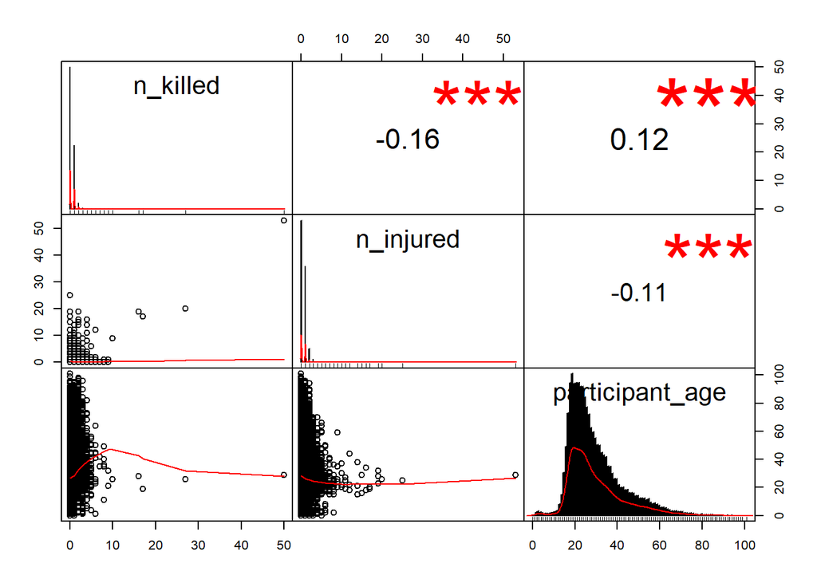

```r
chart.Correlation(dfnum, histogram=TRUE, pch=19)
```

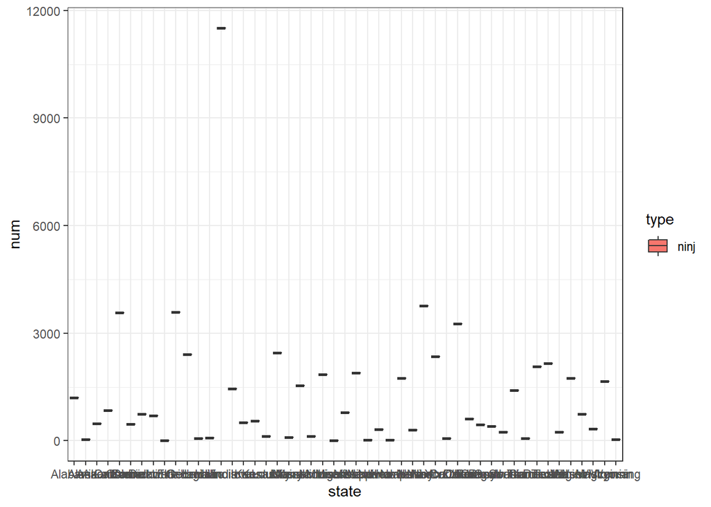

```r
bystateinj <- df2 %>% group_by(state) %>% summarize(n = n(), ninj = sum(n_injured)) %>% tidyr::gather(key = "type", value = "num", ninj)
ggplot(bystateinj, aes(x = state, y = num, fill = type)) + geom_boxplot() + theme_bw()
```

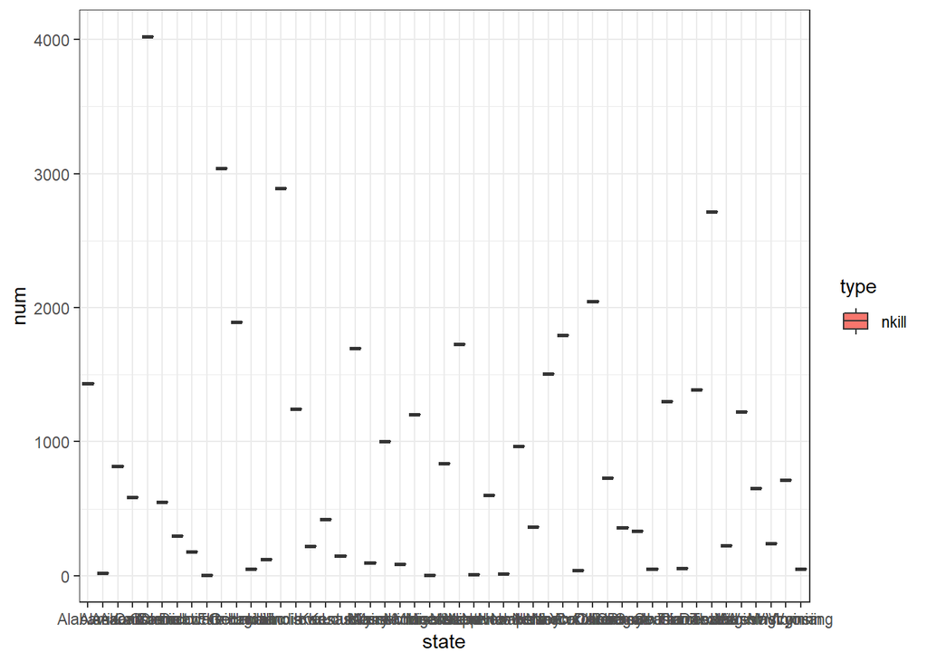

```r
bystatekill <- df2 %>% group_by(state) %>% summarize(n = n(), nkill = sum(n_killed))%>% tidyr::gather(key = "type", value = "num", nkill)
ggplot(bystatekill, aes(x = state, y = num, fill = type)) + geom_boxplot() + theme_bw()
```

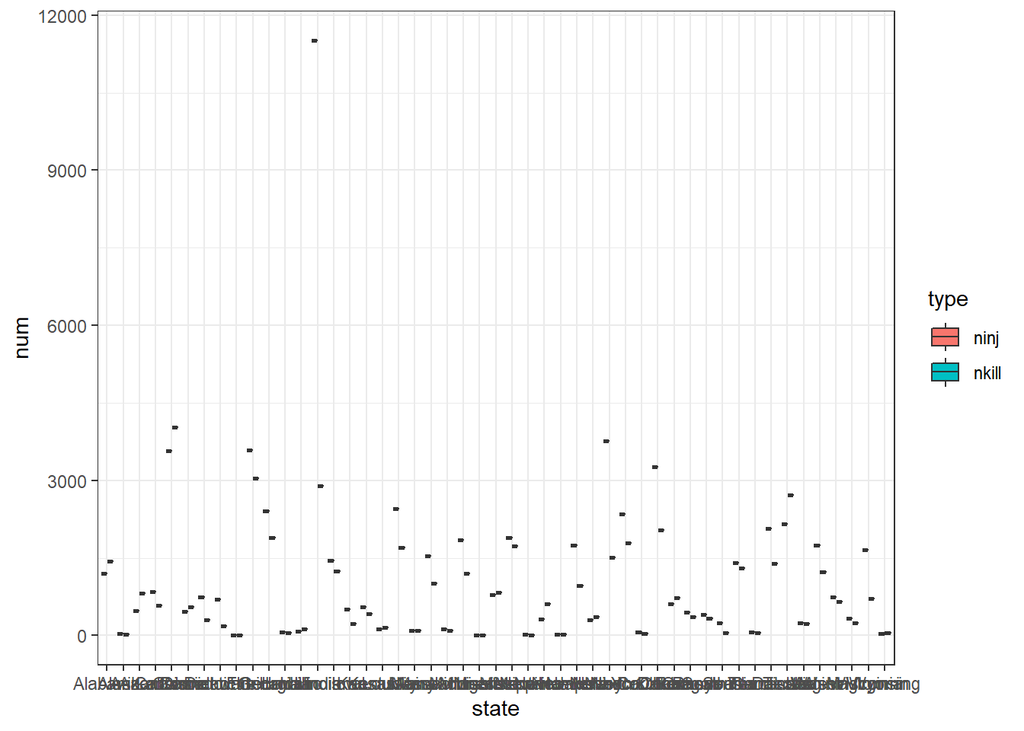

```r
bystate <- df2 %>% group_by(state) %>% summarize(n = n(), nkill = sum(n_killed), ninj = sum(n_injured)) %>% tidyr::gather(key = "type", value = "num", nkill, ninj)
ggplot(bystate, aes(x = state, y = num, fill = type)) + geom_boxplot() + theme_bw()
```

### Deuxième question :

#### Prenez les données de la période entre le 1er janvier 2013 et le 31 décembre 2017 pour calculer les quantités statistiques (moyenne, écart type, etc) et considérez les données entre le 1 janvier 2018 et le 31 mars 2018 comme un échantillon. Est-ce que l’on peut dire que les valeurs moyens des variables dans V ont significativement changé par rapport au passé ?

Nous commençons par séléctionner la partie de la data que nous avons besoin (la période entre le 1er janvier 2013 et le 31 décembre 2017 et celle entre le 1 janvier 2018 et le 31 mars 2018) :

```r
#Prenons les datas df1 avec les colonnes utiles
data <- subset(df1, select = c(n_killed, n_injured, state, participant_age, date))

#et prenons les datas recueillis en 2018 (01-01-2018 -> 31-12-2018)
data_2018 <- subset(data, data$date >= as.Date('2018-01-01') & data$date <= as.Date('2018-03-31'))

#Pour la période suivante : 01-01-2013 -> 31-12-2017
data_With_Periode <- subset(data, data$date >= as.Date('2013-01-01') & data$date <= as.Date('2017-12-31'))



#Etudions plus en détail ce jeu de données
summary(data_With_Periode)
```

```
##     n_killed         n_injured          state           participant_age
##  Min.   : 0.0000   Min.   : 0.0000   Length:106480      Min.   :  0.00
##  1st Qu.: 0.0000   1st Qu.: 0.0000   Class :character   1st Qu.: 21.00
##  Median : 0.0000   Median : 0.0000   Mode  :character   Median : 26.00
##  Mean   : 0.3777   Mean   : 0.5534                      Mean   : 29.63
##  3rd Qu.: 1.0000   3rd Qu.: 1.0000                      3rd Qu.: 35.00
##  Max.   :50.0000   Max.   :53.0000                      Max.   :209.00
##                                                         NA's   :1597
##      date
##  Length:106480
##  Class :character
##  Mode  :character
##
##
##
##
```

```r
#a voir si on peut améliorer cette partie

#Considérons l'échantillon suivant : data_2018
summary(data_2018)
```

```
##     n_killed         n_injured          state           participant_age
##  Min.   : 0.0000   Min.   : 0.0000   Length:6120        Min.   : 0.00
##  1st Qu.: 0.0000   1st Qu.: 0.0000   Class :character   1st Qu.:21.00
##  Median : 0.0000   Median : 0.0000   Mode  :character   Median :27.00
##  Mean   : 0.3956   Mean   : 0.4667                      Mean   :30.41
##  3rd Qu.: 1.0000   3rd Qu.: 1.0000                      3rd Qu.:37.00
##  Max.   :17.0000   Max.   :17.0000                      Max.   :94.00
##      date
##  Length:6120
##  Class :character
##  Mode  :character
##
##
##
```

Si nous comparons les résultats, nous remarquons les choses suivantes :

H0 NB MORT : Le nombre de morts obtenus en 2018 a permis de modifier la moyenne de mort HO NB BLESSE : Le nombre de blesses obtenus en 2018 a permis de modifier la moyenne de blesses HO AGE PARTICIPANT : L’age des participants releves en 2018 a permis de modifier la moyenne d’age

Nous etablissons nos fonctions au préalable ainsi elles faciliterons le traitement et ce sera plus lisible pour la suite.

```r
RejectRegion <- function(mu, n, xbar, sigma) {
  res = abs(xbar-mu)/(sigma/sqrt(n))
  return(res)
}

p_value <- function(alpha, ddl) {
  pval = qt(alpha, df=ddl, lower.tail = FALSE)
  return(pval)
}

sigma_value <- function(data) {
  res = var(data)
  return(res)
}
```

#### Le debut des tests :

```r
#taille de l'echantillon
n <- length(data_2018)
# On trouve notre valeur de comparaison (P-value) avec alpha = 5%
tPVAL <- p_value(0.05, n-1)
```

Pour H0 NB MORT : Le nombre de morts obtenus en 2018 a permis de modifier la moyenne de mort

```r
#d'après les resultats obtenus, on a :
mu_NbMort <- mean(data_2018$n_killed)
Xbar_NbMort <- mean(data_With_Periode$n_killed)
sigma_NbMort <- sigma_value(data_2018$n_killed)

# On applique notre test avec les données obtenues
t_NbMort <- RejectRegion(mu_NbMort, n, Xbar_NbMort, sigma_NbMort)

# On compare et on regarde le résultat
if(t_NbMort >= -tPVAL && t_NbMort <= tPVAL) {
  cat("pour alpha = 5%, on a t_nbMort (", t_NbMort ,") appartenant à l'intervalle [",
      -tPVAL , ";", tPVAL, "]\n-> Ainsi, on ne peut pas refuser H0\n")
} else {
  cat("pour alpha = 5%, on a t_nbMort (", t_NbMort ,") n'appartenant pas à l'intervalle [",
      -tPVAL , ";", tPVAL, "]\n-> Ainsi,on rejette H0\n")
}
```

```
## pour alpha = 5%, on a t_nbMort ( 0.09824325 ) appartenant à l'intervalle [ -2.131847 ; 2.131847 ]
## -> Ainsi, on ne peut pas refuser H0
```

#### Conclusion : pour alpha = 5%, on a t_nbMort ( 0.09824325 ) appartenant à l’intervalle [ -2.131847 ; 2.131847 ]

#### Ainsi, on ne peut pas refuser H0

Pour HO NB BLESSE : Le nombre de blesses obtenus en 2018 a permis de modifier la moyenne de blesses

```r
#d'après les resultats obtenus, on a :
mu_NbBlesses <- mean(data_2018$n_injured)
Xbar_NbBlesses <- mean(data_With_Periode$n_injured)
sigma_NbBlesses <- sigma_value(data_2018$n_injured)

# On applique notre test avec les données obtenues
t_NbBlesses <- RejectRegion(mu_NbBlesses, n, Xbar_NbBlesses, sigma_NbBlesses)

# On compare et on regarde le résultat
if(t_NbBlesses >= -tPVAL && t_NbBlesses <= tPVAL) {
  cat("pour alpha = 5%, on a t_nbMort (", t_NbBlesses ,") appartenant à l'intervalle [",
      -tPVAL , ";", tPVAL, "]\n-> Ainsi, on ne peut pas refuser H0\n")
} else {
  cat("pour alpha = 5%, on a t_nbMort (", t_NbBlesses ,") n'appartenant pas à l'intervalle [",
      -tPVAL , ";", tPVAL, "]\n-> Ainsi,on rejette H0\n")
}
```

```
## pour alpha = 5%, on a t_nbMort ( 0.3726553 ) appartenant à l'intervalle [ -2.131847 ; 2.131847 ]
## -> Ainsi, on ne peut pas refuser H0
```

#### Conclusion : pour alpha = 5%, on a t_nbMort ( 0.3726553 ) appartenant à l’intervalle [ -2.131847 ; 2.131847 ]

Pour HO AGE PARTICIPANT : L’age des participants releves en 2018 a permis de modifier la moyenne d’age

```r
#d'après les resultats obtenus, on a :
mu_Age <- mean(data_2018$participant_age)
Xbar_Age <- 29.63 # mean(data_With_Periode$participant_age) la cmd ne marche pas ... à voir
#tmp : on la saisie à la main
sigma_Age <- sigma_value(data_2018$participant_age)

# On applique notre test avec les données obtenues
t_Age <- RejectRegion(mu_Age, n, Xbar_Age, sigma_Age)

# On compare et on regarde le résultat
if(t_Age >= -tPVAL && t_Age <= tPVAL) {
  cat("pour alpha = 5%, on a t_nbMort (", t_Age ,") appartenant à l'intervalle [",
      -tPVAL , ";", tPVAL, "]\n-> Ainsi, on ne peut pas refuser H0\n")
} else {
  cat("pour alpha = 5%, on a t_nbMort (", t_Age ,") n'appartenant pas à l'intervalle [",
      -tPVAL , ";", tPVAL, "]\n-> Ainsi,on rejette H0\n")
}
```

```
## pour alpha = 5%, on a t_nbMort ( 0.01011114 ) appartenant à l'intervalle [ -2.131847 ; 2.131847 ]
## -> Ainsi, on ne peut pas refuser H0
```

#### Conclusion : pour alpha = 5%, on a t_nbMort ( 0.01011114 ) appartenant à l’intervalle [ -2.131847 ; 2.131847 ]

#### Ainsi, on ne peut pas refuser H0

## Présentation des membres :